# Primer of Ecology with $\textsf{R}$: chapter 3

Compiled on Fri Aug 16 11:24:29 2019 by ohara

```r
knitr::opts_chunk$set(fig.width = 6, fig.height = 4, # fig.path = 'Figs/',
                      echo = TRUE, message = FALSE, warning = FALSE)

library(tidyverse)
library(RColorBrewer)

### The book has an R package!
library(primer) # install.packages('primer')
```

# Chapter 3: Density Dependent Growth

## 3.1 Discrete Density-dependent Growth

### 3.1.1 Writing a Function For Discrete Logistic Growth

```r
dlogistic <- function(alpha = 0.01, rd = 1, N0 = 2, t = 15) {
  N <- c(N0, numeric(t))
  for (i in 1:t) N[i + 1] <- {
      N[i] + rd * N[i] * (1 - alpha * N[i])
    }

  return(N)
}
### The function first makes a new vector containing N0,
### uses a for-loop to implement eq. 3.7 for each time step, and
### then returns the vector N.
```

### 3.1.1. Graphing Population Size

We can use the function created above, `dlogistic`, with default settings, to generate a population projection.

```r
Nts <- dlogistic()
```

Now we plot the projection, and put in a dotted line for $1/\alpha$ or $K$.

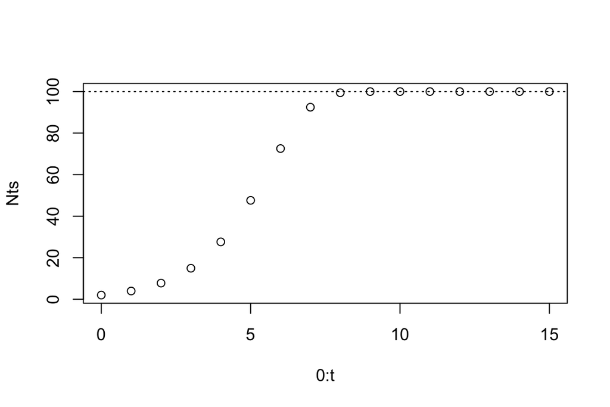

```r
t <- 15
a <- 0.01
plot(0:t, Nts)
abline(h = 1/a, lty = 3)
```

### 3.1.2 (Per Capita) Population Growth Increment vs. N (Fig. 3.3)

Using the previous projection, we now capture both the total and the per capita growth increment per unit time, from $t$ to $t+1$. We graph these versus $N_t$, population size at $t$.

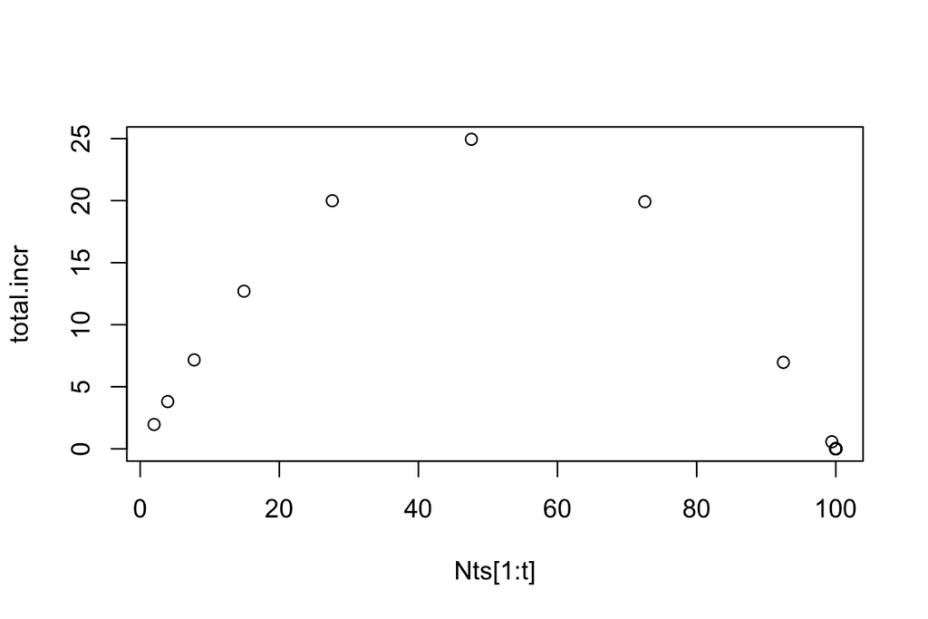

```r
total.incr <- Nts[1:t + 1] - Nts[1:t]
per.capita.incr <- total.incr/Nts[1:t]
plot(Nts[1:t], total.incr)
```

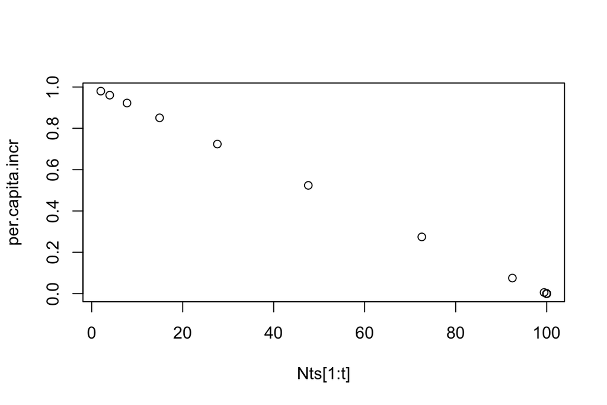

```r
plot(Nts[1:t], per.capita.incr)
```

### 3.1.3 Numerical Evaluation of Initial Conditions (Fig. 3.4a)

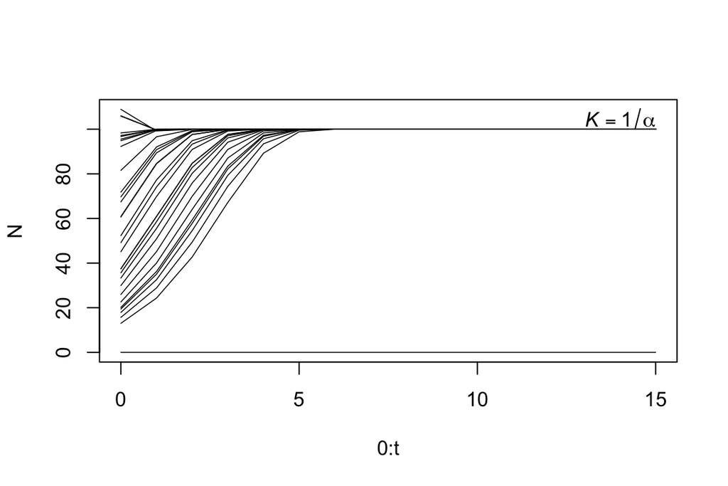

```r
N0s <- c(0, runif(30) * 1.1 * 1/a)
N <- sapply(N0s, function(n) dlogistic(N0 = n))
matplot(0:t, N, type = "l", lty = 1, lwd = 0.75, col = 1)
text(t, 1/a, expression(italic("K") == 1/alpha), adj = c(1, 0))
```

A serious simulation might include a much larger number of $N_0$.

### 3.1.4 Numerical Evaluation of $\alpha$ (Fig. 3.4b)

Here we draw 30 random $K$ from a uniform distribution from 50 to 1000, and convert these to $\alpha$. We use sapply to run `dlogistic` for each $\alpha$.

```r
a.s <- 1/runif(30, min = 50, max = 1000)

N <- sapply(a.s, function(a) dlogistic(alpha = a, t = 15))
```

We next plot all populations, and use some fancy code to add some informative text in the right locations.

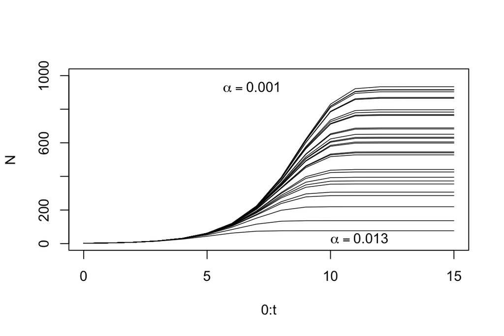

```r
matplot(0:t, N, type = "l", ylim = c(0, 1000),
        lty = 1, lwd = 0.75, col = 1)
text(8, 1/min(a.s), bquote(italic(alpha) == .(round(min(a.s), 3))),
     adj = c(1, 0.5))
text(10, 1/max(a.s), bquote(italic(alpha) == .(round(max(a.s),  3))),
     adj = c(0, 1.2))
```

Note that we use the minimum and maximum of `a.s` to both position the text, and provide the values of the smallest and largest $\alpha$.

### 3.1.5 Simple Numerical Evaluation of rd (Fig. 3.5)

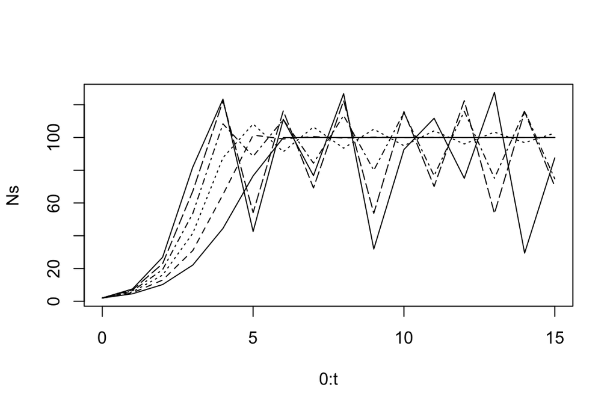

```r
rd.v <- seq(1.3, 2.8, by = 0.3)
t <- 15

Ns <- data.frame(sapply(rd.v, function(r) dlogistic(rd = r, t = t)))

matplot(0:t, Ns, type = "l", col = 1)
```

Note that many populations do not seem to settle down at $K$.

### 3.1.5 Presentation of Limit Cycles (Fig. 3.6)

First we make a data frame with the six $r_d$ values in the first column, and the respective populations in rows, using `t()` to transpose `Ns`. This puts the data in wide format, with a different time step in each column. (This might, for instance, be how you record data in a field experiment with repeated measurements through time).

```r
tmp <- data.frame(rd = as.factor(rd.v), t(Ns))
```

Next, we reshape the data to long format, were all $N$ are in the second column, and each is associated with a time step and its $r_d$ value (cols. 3 and 4).

```r
Ns2 <- reshape(tmp, varying = list(2:ncol(tmp)),
               idvar = "rd", v.names = "N", direction = "long")
# str(Ns2)
```

… (output omitted) We plot each trajectory separately using xyplot in a different graphics package, lattice. Known as a conditioning plot, xyplot graphs $y$ vs. $x$ conditional on $g$ $(y \sim x | g)$.

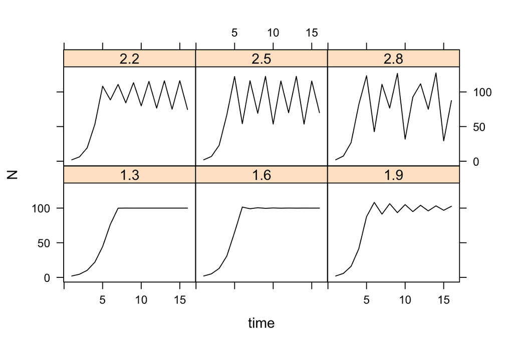

```r
library(lattice)
print(xyplot(N ~ time | rd, data = Ns2, type = "l",
             layout = c(3, 2, 1), col = 1))
```

### 3.1.5 Bifurcation Plot: Attractors as a Function of $r_d$ (Fig. 3.7)

Here we perform more comprehensive simulations, and plot the point and periodic attractors vs. $r_d$. First we pick some constraints for the simulation: the number of different $r_d$, the sequence of $r_d$ values, and the number of time steps.

```r
num.rd <- 201; t <- 400
rd.s <- seq(1, 3, length = num.rd)
```

Next we use sapply for the simulations.

```r
tmp <- sapply(rd.s, function(r) dlogistic(rd = r, N0 = 99, t = t))
```

Next we convert the output to a data frame and stack up the $N$ in one column. We also rename each of the stacked columns, and add new columns for the respective $r_d$ and time steps.

```r
tmp.s <- stack(as.data.frame(tmp))
names(tmp.s) <- c("N", "Old.Column.ID")
tmp.s$rd <- rep(rd.s, each = t + 1)
tmp.s$time <- rep(0:t, num.rd)
```

We save just the later dynamics in order to focus on the $N$ after they have converged on the periodic attractors. Here we select the last 50% of the time steps. (Your figure will look a little different than Fig. 3.7 because I used more $r_d$ and time steps.)

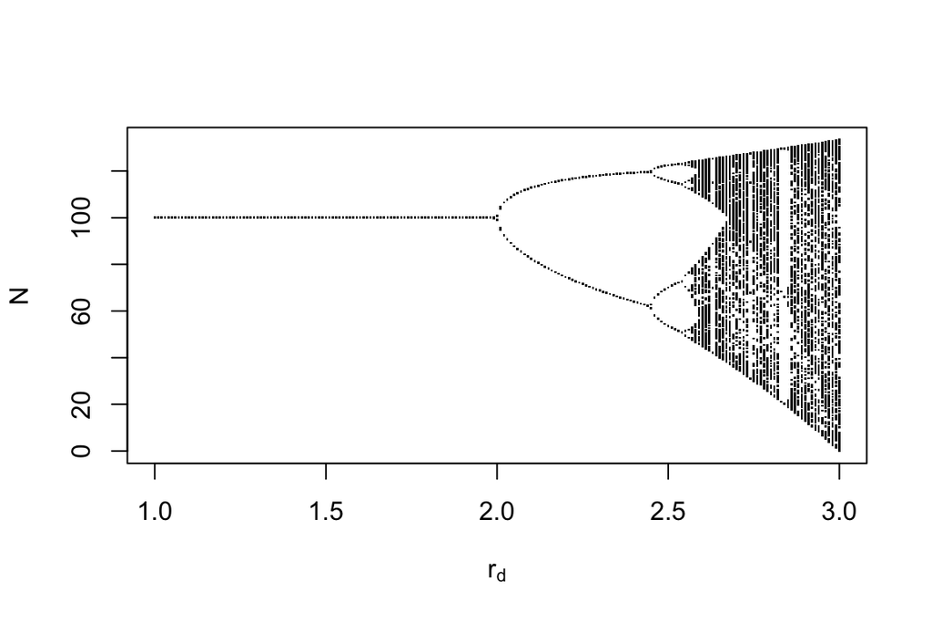

```r
N.bif <- subset(tmp.s, time > 0.5 * t)
plot(N ~ rd, data = N.bif, pch = ".", xlab = quote("r"["d"]))
```

### 3.1.5 Sensitivity to Intitial Conditions

```r
N.init <- c(97, 98, 99); t <- 30
Ns <- sapply(N.init, function(n0) dlogistic(rd = 2.7, N0 = n0,  t = t))
```

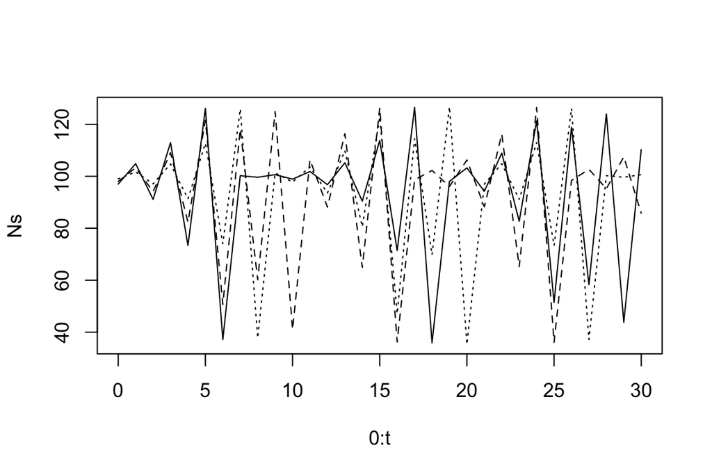

```r
matplot(0:t, Ns, type = "l", col = 1)
```

## 3.2 Continuous Density Dependent Growth

### 3.2.1 Density Dependence on Birth and Death Rates (Figs. 3.9a, 3.9b)

To make expressions for eqs. 3.21, 3.20, use `expression`.

```r
B.N <- expression(-a * N^2 + e * N - f)
D.N <- expression(g * N^2)
```

We then provides constants and evaluate the expressions to plot the density dependence on birth and death rates.

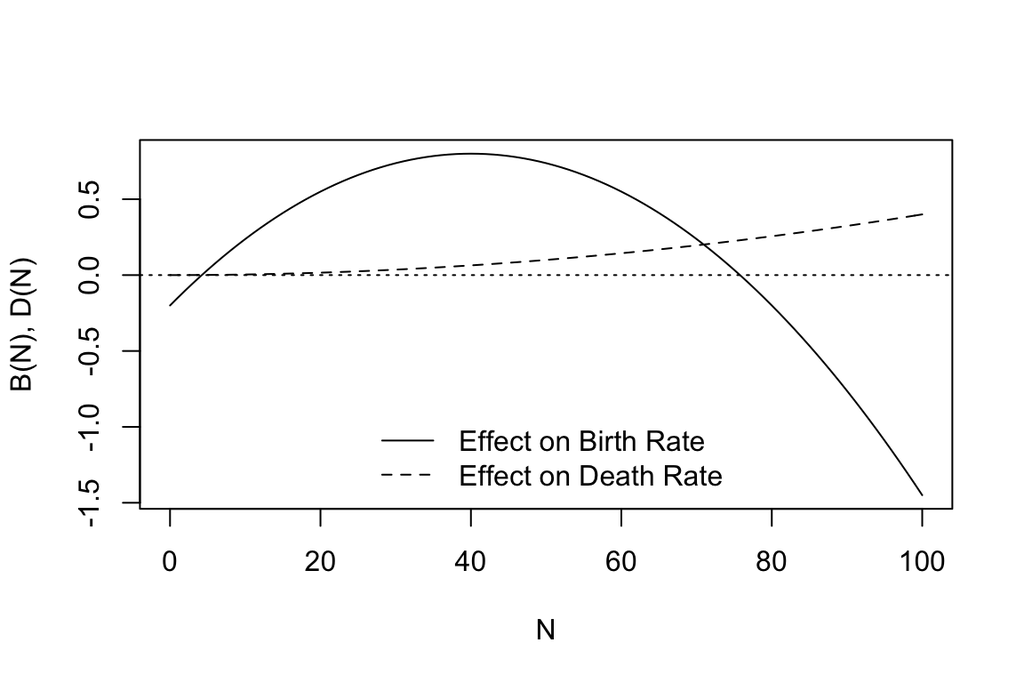

```r
a <- 1/1600; e <- 80 * a; f <- 0.2; g <- 4e-05; N <- 0:100

plot(N, eval(B.N), type = "l", ylab = "B(N), D(N)")
lines(N, eval(D.N), lty = 2)
abline(h = 0, lty = 3)
legend("bottom", c("Effect on Birth Rate", "Effect on Death Rate"),
       lty = 1:2, bty = "n")
```

The sum of these two rates is merely density dependence,

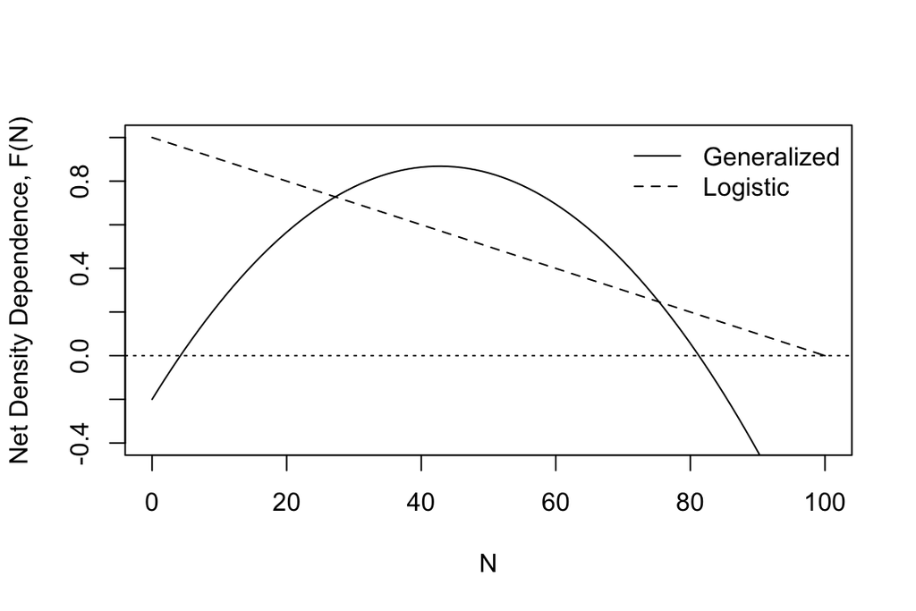

```r
plot(N, eval(B.N) + eval(D.N), type = "l", ylim = c(-0.4, 1),
     ylab = "Net Density Dependence, F(N)")
abline(h = 0, lty = 3)
### and we can compare this to linear density dependence of the logistic
### model (1 - alpha N). If alpha = 0.01, we have
curve(1 - 0.01 * x, 0, 100, lty = 2, add = T)
legend("topright", c("Generalized", "Logistic"), lty = 1:2,
       bty = "n")
```

### 3.2.3 Growth rate vs. $N$

We first define an expression, and constants.

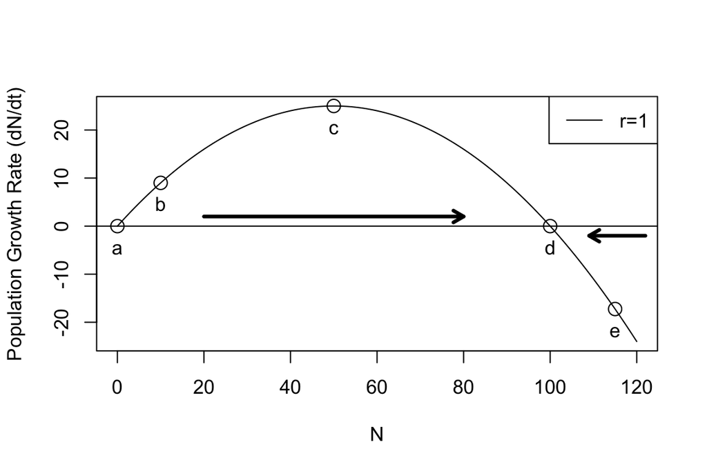

```r
pop.growth.rate <- expression(r * N * (1 - alpha * N))
r <- 1; alpha <- 0.01; N <- 0:120

### A basic plot.
plot(N, eval(pop.growth.rate), type = "l",
     ylab = "Population Growth Rate (dN/dt)", xlab = "N")
abline(h = 0); legend("topright", "r=1", lty = 1)

### Add a few points with labels,
N <- c(0, 10, 50, 100, 115)
points(N, eval(pop.growth.rate), cex = 1.5)
text(N, eval(pop.growth.rate), letters[1:5], adj = c(0.5, 2))

### and arrows for the direction of change in N.
arrows(20, 2, 80, 2, length = 0.1, lwd = 3)
arrows(122, -2, 109, -2, length = 0.1, lwd = 3)
```

### 3.2.3 Symbolic differentiation

We can use $\textsf{R}$’s minimal symbolic capabilities to get derivatives. Here we get the partial derivative and evaluate for the two equilibria (Fig. 3.10).

```r
dF.dN <- deriv(pop.growth.rate, "N")
N <- c(0, 1/alpha)
eval(dF.dN)
```

```
## [1] 0 0
## attr(,"gradient")
##       N
## [1,]  1
## [2,] -1
```

The first value, 1, corresponds to the first value of $N$, which is 0. Because it is positive, this indicates that the perturbation will increase with time, meaning that $N$ = 0 is a repellor. The second value, −1, is negative, and so indicates that the perturbation will decrease with time, meaning that $N = 1/\alpha$ is an attractor.

### 3.2.4 Function for an ODE

Making a function to use with $\textsf{R}$’s ODE solver is pretty easy, provided we follow the rules (see Appendix, secs. , B.10). To make the code transparent, I translate the vector parameters and the vector of populations (in this single species model, we have only one population).

```r
clogistic <- function(times, y, parms) {
  n <- y[1]
  r <- parms[1]
  alpha <- parms[2]
  dN.dt <- r * n * (1 - alpha * n)

  return(list(c(dN.dt)))
}
```

We create vectors for the parameters and the initial densities for all of the populations in the model. We also specify the time.

```r
prms <- c(r = 1, alpha = 0.01)
init.N <- c(1)
t.s <- seq(0.1, 10, by = 0.1)
```

We load the `deSolve` library, and run `ode`. The output is a matrix that includes the time steps and the $N$ (Fig. 3.12a).

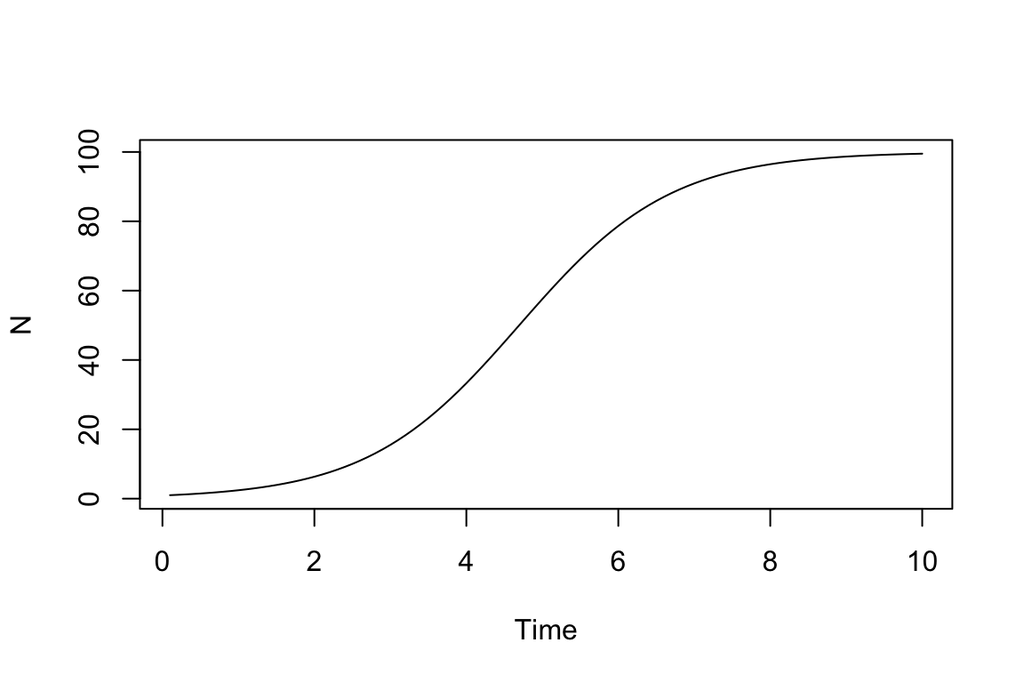

```r
library(deSolve)

out <- ode(y = init.N, times = t.s, clogistic, parms = prms)

plot(out[, 1], out[, 2], type = "l", xlab = "Time", ylab = "N")
```

### 3.2.4 Plotting Random Populations (Fig. 3.12b)

We use the above function to create 20 populations with different traits. We start with an empty matrix, and then for each of the populations, we draw random $N_0$ and $r$, run the ODE solver, keeping just the column for $N$. Last we plot the output.

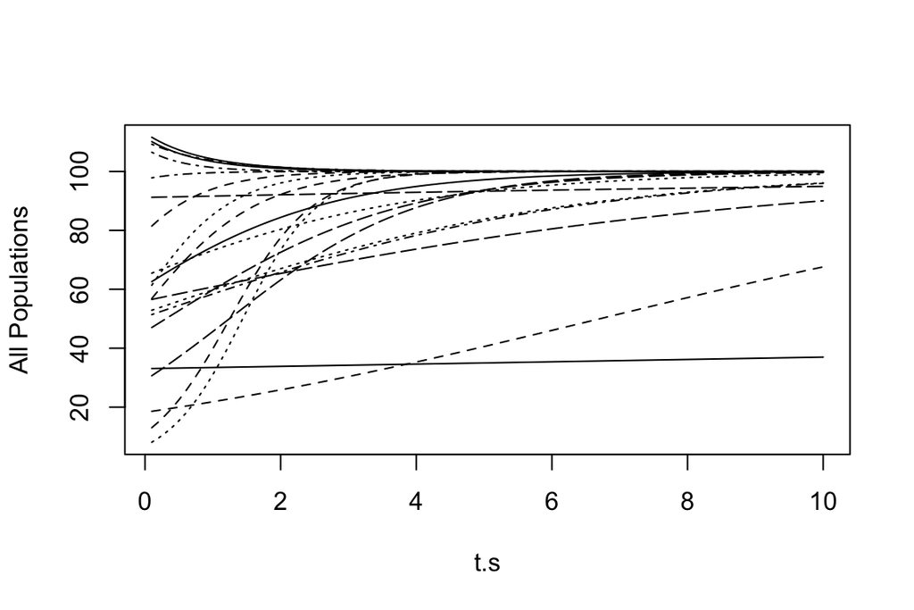

```r
outmat <- matrix(NA, nrow = length(t.s), ncol = 20)
for (j in 1:20) outmat[, j] <- {
  y <- runif(n = 1, min = 0, max = 120)
  prms <- c(r = runif(1, 0.01, 2), alpha = 0.01)
  ode(y, times = t.s, clogistic, prms)[, 2]
}
matplot(t.s, outmat, type = "l", col = 1, ylab = "All Populations")
```

## 3.3 Other Forms of Density-dependence

### 3.3.0 Theta-logistic function

Here we make a function that we can use with `ode`, the numerical integration function.

```r
thetalogistic <- function(times, y, parms) {
  n <- y[1]
  with(as.list(parms), {
    dN.dt <- r * n * (1 - (alpha * n)^theta)
    return(list(c(dN.dt)))
  })
}
```

Using `with()` and `as.list()` creates an environment in which $\textsf{R}$ will look inside `parms` for named elements. This will work as long as we name the parameters in `parms`.

### 3.3.0 Theta-logistic density dependence

We first graph theta-logistic, for $\theta$ < 1, $\theta$ = 1, and $\theta$ > 1 (Fig. 3.13a).

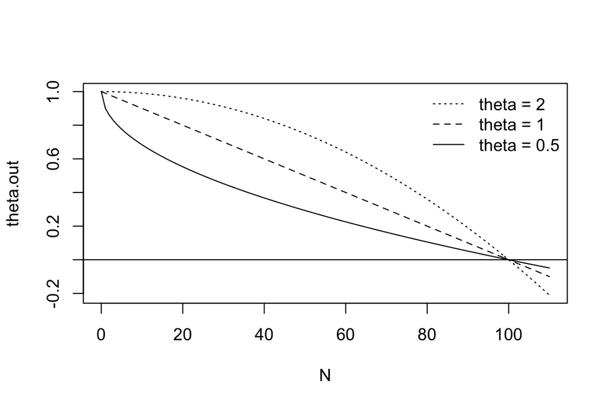

```r
r <- 0.75
alpha <- 0.01
theta <- c(0.5, 1, 2)
N <- 0:110
theta.out <- sapply(theta, function(th) {
  1 - (alpha * N)^th
})

matplot(N, theta.out, type = "l", col = 1)
abline(h = 0)
legend("topright", legend = paste("theta =", c(2, 1, 0.5)),
       lty = 3:1, bty = "n")
```

### 3.3.0 Theta-logistic growth rate

We plot the growth rate (a.k.a. the production function) for the theta-logistic model with $\theta$ < 1, $\theta$ = 1, and $\theta$ > 1 (Fig. 3.13b).

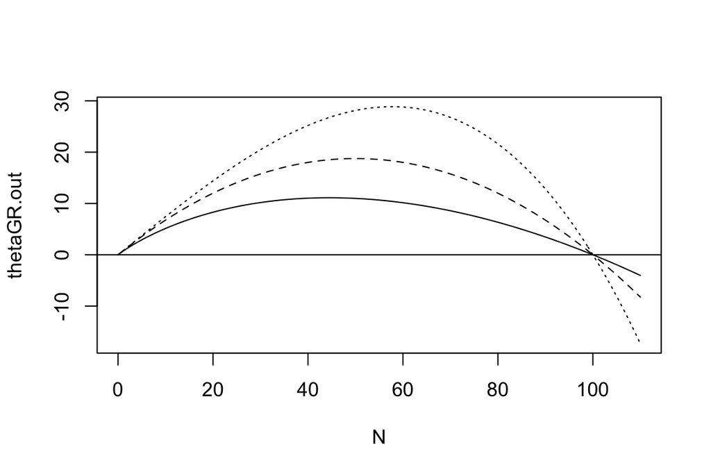

```r
thetaGR.out <- sapply(theta, function(th) {
  r * N * (1 - (alpha * N)^th)
})

matplot(N, thetaGR.out, type = "l", col = 1)
abline(h = 0)
```

### 3.3.0 Theta-logistic dynamics

We solve numerically for $N$, and plot the dynamics for $N$ with $\theta$ < 1, $\theta$ = 1, and $\theta$ > 1 (Fig. 3.13c).

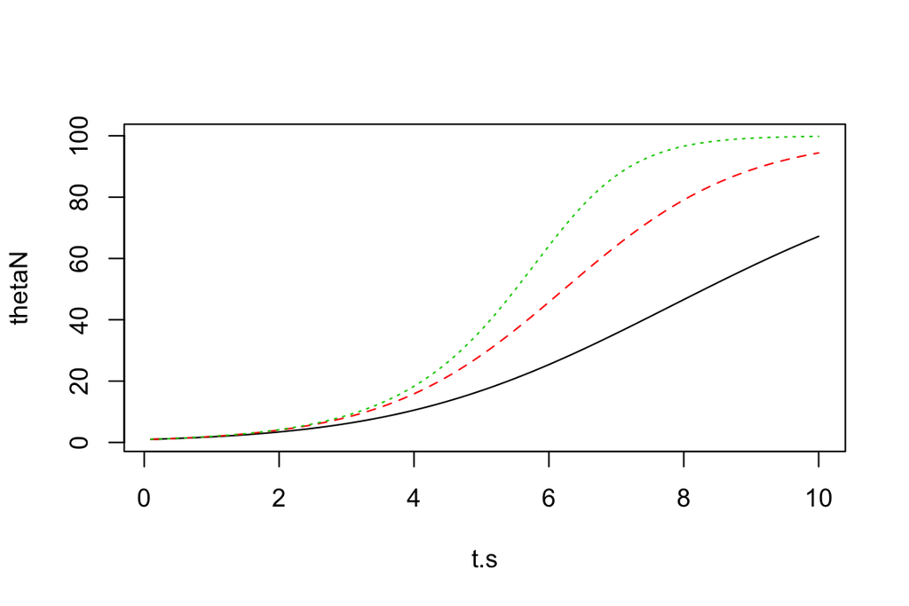

```r
prms <- c(r = 0.75, alpha = 0.01, theta = 1)
thetaN <- sapply(theta, function(th) {
  prms["theta"] <- th
  ode(y = 1, t.s, thetalogistic, prms)[, 2]
})

matplot(t.s, thetaN, type = "l")
```

## 3.4 Maximum Sustained Yield

### 3.4.0 MSY and harvesting (Fig. 3.14a)

Here we illustrate the interaction harvesting at a rate associated with $MSY$ for logistic growth. We set logistic model parameters, and first plot logistic growth without harvest.

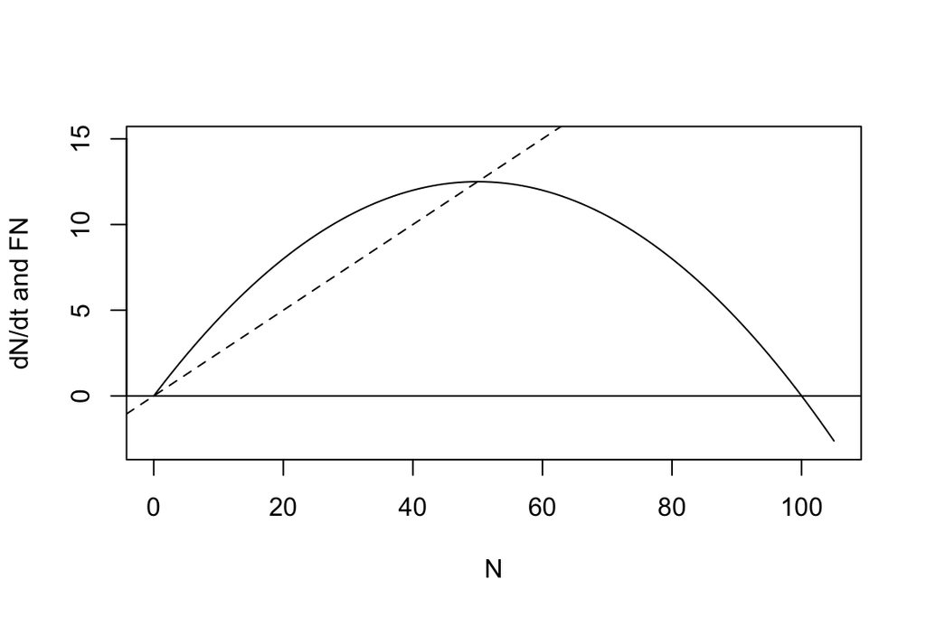

```r
r <- 0.5; alpha <- 0.01; N <- 0:105
plot(N, eval(pop.growth.rate), type = "l", ylim = c(-3, 15),
     ylab = "dN/dt and FN")
abline(h = 0)
### We then calculate F based on our solution eq. 9.6, and plot the
### linear harvest function with an intercept of zero, and slope of F.
F <- r/2
abline(c(0, F), lty = 2)
```

### 3.4.0 Equilibrium solution for logistic growth with harvesting (Fig. 3.14b)

When we add harvesting at rate $F = r/2$, we get a new equilibrium. Here we illustrate this using the same parameters as above, but now using the entire function with both growth and harvest.

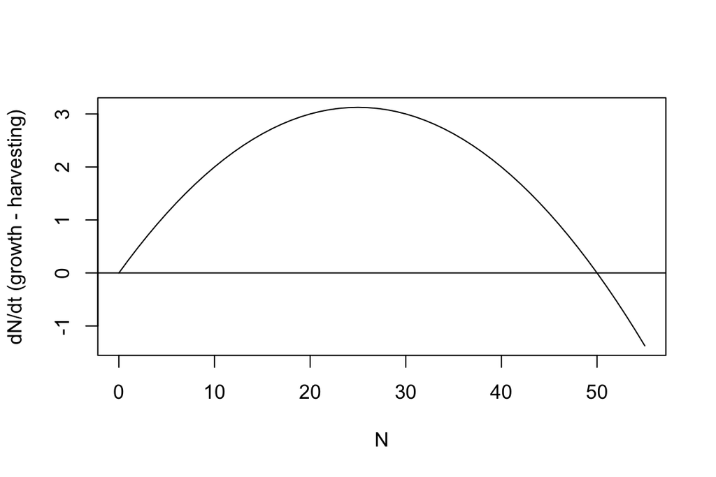

```r
pgr.H <- expression(r * N * (1 - alpha * N) - F * N)
N <- 0:55

plot(N, eval(pgr.H), type = "l", ylab = "dN/dt (growth - harvesting)")
abline(h = 0)
```

This merely represents the new equilibrium (where $dN/dt$ crosses the $x$-axis) with a harvest of rate $F = r/2$.

## 3.5 Fitting Models to Data

### 3.5.1 The role of resources in altering population interactions within a simple food web

Increasing resource availability may increase or, paradoxically, decrease the populations that use those resources [176,179,200]. Here we explore how adding resources influences the strength of per capita denisty dependence, $\alpha$, of an alga, *Closterium acerosum*, embedded in a simple food web [195].

…

Here, we will explore the effects of the resource supply rate on two parameters of linear density dependence (logistic growth) $r$ and $\alpha$ of *Closterium acerosum.*

### 3.5.2 Initial data exploration

First we load two more libraries, the data, and check a summary.

```r
library(nlme)
library(lattice)
data(ClostExp)
summary(ClostExp)
```

```
##  Nutrients   No.per.ml            Day        rep          ID
##  high:72   Min.   :   1.00   Min.   : 1.00   a:36   a.low  :18
##  low :72   1st Qu.:  16.17   1st Qu.:11.00   b:36   d.low  :18
##            Median :  41.98   Median :26.00   c:36   c.low  :18
##            Mean   : 131.50   Mean   :25.94   d:36   b.low  :18
##            3rd Qu.: 141.54   3rd Qu.:39.00          c.high :18
##            Max.   :1799.11   Max.   :60.00          a.high :18
##                                                     (Other):36
```

```r
#  Nutrients   No.per.ml           Day       rep          ID
#  high:72   Min.   :   1.0   Min.   : 1.0   a:36   a.low  :18
#  low :72   1st Qu.:  16.2   1st Qu.:11.0   b:36   d.low  :18
#            Median :  42.0   Median :26.0   c:36   c.low  :18
#            Mean   : 131.5   Mean   :25.9   d:36   b.low  :18
#            3rd Qu.: 141.5   3rd Qu.:39.0          c.high :18
#            Max.   :1799.1   Max.   :60.0          a.high :18
# (Other):36
```

Next we plot each replicate of the high and low nutrient treatments.

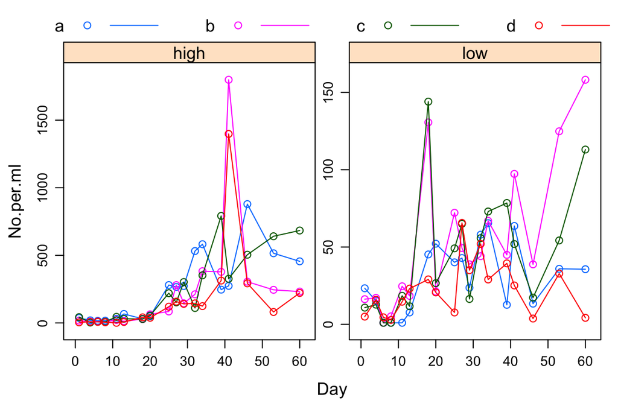

```r
xyplot(No.per.ml ~ Day | Nutrients, ClostExp, groups = rep,
       type = "b", scales = list(relation = "free"),
       auto.key = list(columns = 4,    lines = T))
```

```r
subset(ClostExp, Nutrients == "high" & No.per.ml > 1000)
```

```
## Grouped Data: No.per.ml ~ Day | ID
##     Nutrients No.per.ml Day rep     ID
## 114      high   1799.11  41   b b.high
## 116      high   1398.44  41   d d.high
```

```r
# Grouped Data: No.per.ml ~ Day | ID
#     Nutrients No.per.ml Day rep     ID
# 114      high      1799  41   b b.high
# 116      high      1398  41   d d.high

subset(ClostExp, Nutrients == "low" & No.per.ml > 100)
```

```
## Grouped Data: No.per.ml ~ Day | ID
##     Nutrients No.per.ml Day rep    ID
## 54        low    130.61  18   b b.low
## 55        low    144.02  18   c c.low
## 134       low    124.85  53   b b.low
## 142       low    158.17  60   b b.low
## 143       low    113.04  60   c c.low
```

```r
# Grouped Data: No.per.ml ~ Day | ID
#     Nutrients No.per.ml Day rep    ID
# 54 low
# 55 low
# 134 low
# 142 low
# 143 low
# 130.6  18   b b.low
# 144.0  18   c c.low
# 124.8  53   b b.low
# 158.2  60   b b.low
# 113.0  60   c c.low
```

### 3.5.3 A time-implicit approach

We will estimate per capita growth rate, pgr, with
$$pgr = \frac{\log (N_{t+i}/N_t)}{i}$$
where $i$ is the time interval between the two population densities [188]. In this and other contexts, logarithm of two populations is sometimes referred to simply as the *log ratio.*

Let’s estimate this for one of the microcosms, high nutrient, replicate $c$.

```r
Hi.c <- subset(ClostExp, Nutrients == "high" & rep == "c")
```

We calculate the differences in density, the time intervals over which these changes occured, and the per capita growth rate.

```r
n <- nrow(Hi.c)
N.change <- Hi.c$No.per.ml[-1]/Hi.c$No.per.ml[-n]
interval <- diff(Hi.c$Day)
pgr <- log(N.change)/interval
```

We can then (i) plot these as functions of $N_t$ (as opposed to $N_{t+1}$), (ii) fit a linear regression model through those points, and (iii) plot that line (Fig. 3.18a).

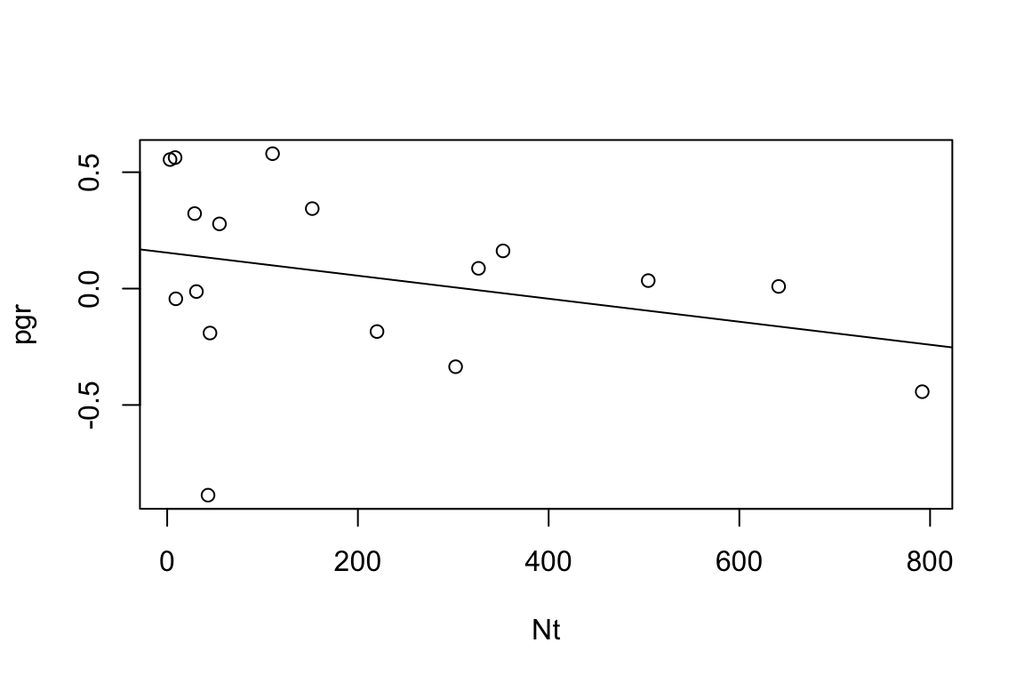

```r
Nt <- Hi.c$No.per.ml[-n]
plot(pgr ~ Nt)
mod1 <- lm(pgr ~ Nt)
abline(mod1)
```

The linear regression model defines a best fit straight line through these points,

```r
summary(mod1)
```

```
##
## Call:
## lm(formula = pgr ~ Nt)
##
## Residuals:
##     Min      1Q  Median      3Q     Max
## -1.0208 -0.2059  0.1292  0.1819  0.4797
##
## Coefficients:
##               Estimate Std. Error t value Pr(>|t|)
## (Intercept)  0.1545565  0.1253272   1.233    0.236
## Nt          -0.0004947  0.0003955  -1.251    0.230
##
## Residual standard error: 0.3824 on 15 degrees of freedom
## Multiple R-squared:  0.09444,    Adjusted R-squared:  0.03407
## F-statistic: 1.564 on 1 and 15 DF,  p-value: 0.2302
```

Now we can do this with all the replicates. Rearranging the data is a bit complicated, but this will suffice. Essentially, we split up the ClostExp data frame into subsets defined by nutrient and replicate ID, and then apply a function that performs all of the steps we used above for a single microcosm. The output will be a list where each component is a new small data frame for each microcosm.

```r
EachPop <- lapply(
  split(ClostExp, list(ClostExp$Nutrients, ClostExp$rep)),
  function(X) {
    n <- nrow(X)
    N.change <- (X$No.per.ml[-1]/X$No.per.ml[-n])
    interval <- diff(X$Day)
    data.frame(Nutrients = as.factor(X$Nutrients[-n]),
               rep = as.factor(X$rep[-n]),
               pgr = log(N.change)/interval, Nt = X$No.per.ml[-n])
  }
)
```

Next we just stack all those individual data frames up into one.

```r
AllPops <- NULL
for (i in 1:length(EachPop)) AllPops <- rbind(AllPops, EachPop[[i]])
```

Finally, we plot all of the microcosms separately.

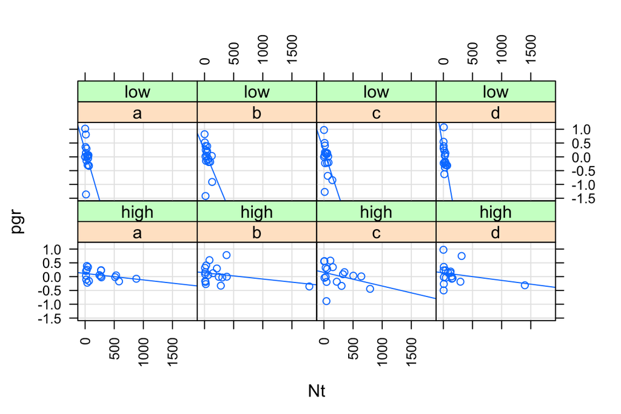

```r
xyplot(pgr ~ Nt | rep * Nutrients, AllPops, layout = c(4, 2, 1),
       scales = list(x = list(rot = 90)),
       panel = function(x, y) {
         panel.grid(h = -1, v = -4)
         panel.xyplot(x, y, type = c("p", "r"))
})
```

### 3.5.3 A statistical model of per capita growth

> footnote: *This section is advanced material. You may want to skim over the parts you don’t understand, and focus on conclusions, or perhaps the general process.*

```r
AllPops$ID <- with(AllPops, Nutrients:rep)
modSlope <- lme(pgr ~ Nt + Nutrients + Nt:Nutrients,
                data = AllPops, random = ~1 | ID)
```

The above code specifies that per capita growth rate, `pgr`, depends in part upon population size, `Nt` — this will be the slope of the `pgr Nt` relation. The effect of nutrient level, `Nutrients`, will simply alter the intercept, or height, of the lines. The code also specifies that the slope the relation can depend upon the nutrient level, `Nt:Nutrients`. Finally, the code also specifies that each microcosm makes its own unique and *random* contribution to the per capita growth rate of its *Closterium* population.

A plot of the residuals vs. the fitted or predicted values should reveal a scatter of points with relatively constant upper and lower bounds.

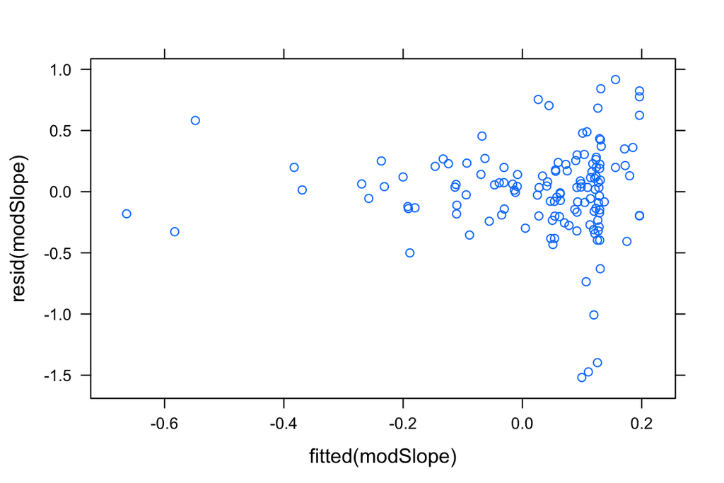

```r
xyplot(resid(modSlope) ~ fitted(modSlope))
```

Our plot (Fig. 3.18a) reveals larger residuals for larger fitted values — this is not good. Quantile-quantile plots of the residuals and random effects should reveal points along a straight diagonal line.

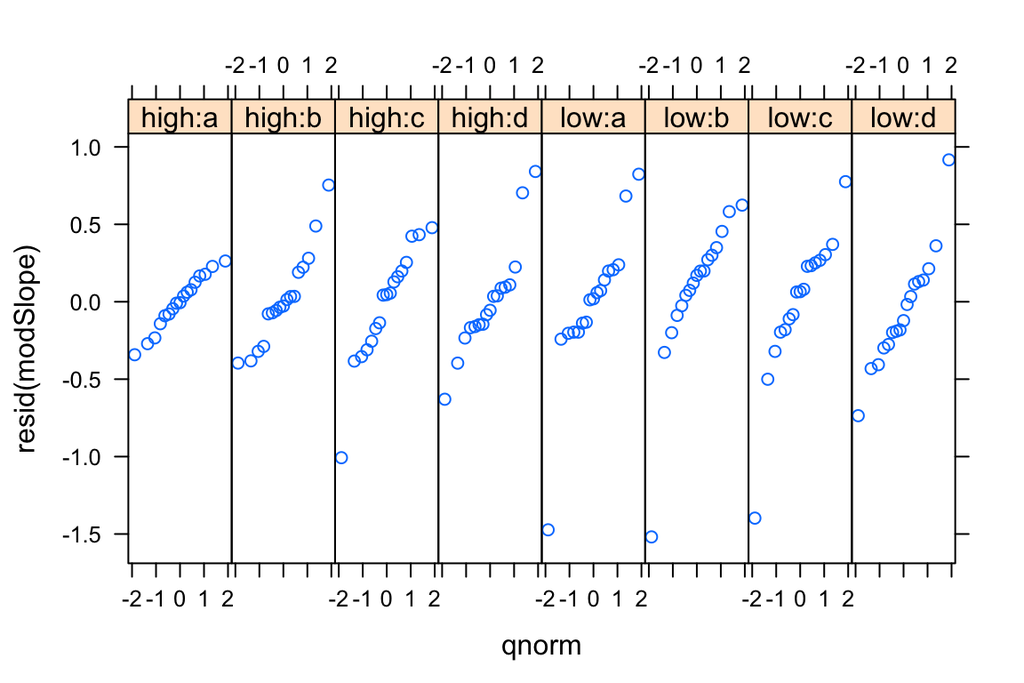

```r
qqmath(~resid(modSlope) | ID, data = AllPops, layout = c(8, 1, 1))
```

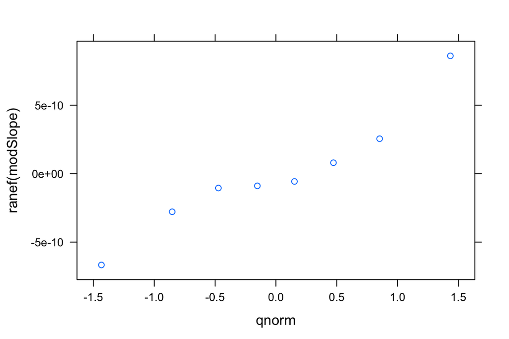

```r
qqmath(~ranef(modSlope))
```

```r
modSlope2 <- update(modSlope, weights = varExp())
```

```r
anova(modSlope, modSlope2)
```

```
##           Model df      AIC      BIC    logLik   Test  L.Ratio p-value
## modSlope      1  6 169.0922 186.3890 -78.54610
## modSlope2     2  7 163.9397 184.1193 -74.96985 1 vs 2 7.152507  0.0075
```

```r
anova(modSlope2)
```

```
##              numDF denDF   F-value p-value
## (Intercept)      1   126  0.823374  0.3659
## Nt               1   126  3.665397  0.0578
## Nutrients        1     6 11.198063  0.0155
## Nt:Nutrients     1   126 27.658833  <.0001
```

```r
summary(modSlope2)$tTable
```

```
##                         Value    Std.Error  DF    t-value      p-value
## (Intercept)      0.1336240593 0.0568610720 126  2.3500095 2.032673e-02
## Nt              -0.0002861293 0.0001146132 126 -2.4964776 1.383427e-02
## Nutrientslow     0.0641174062 0.0878452177   6  0.7298907 4.929570e-01
## Nt:Nutrientslow -0.0056022751 0.0010652401 126 -5.2591666 6.014258e-07
```

```r
cfs <- fixef(modSlope2)
cfs
```

```
##     (Intercept)              Nt    Nutrientslow Nt:Nutrientslow
##    0.1336240593   -0.0002861293    0.0641174062   -0.0056022751
```

```r
-cfs[2]/cfs[1]
```

```
##        Nt
## 0.0021413
```

```r
-(cfs[2] + cfs[4])/(cfs[1] + cfs[3])
```

```
##        Nt
## 0.0297783
```

### 3.5.4 A time-explicit approach

First, we code in $\textsf{R}$ a model of eq. 3.25, that is, logistic growth with parameters $\alpha$, $r$, and $N_0$.

```r
ilogistic <- function(t, alpha, N0, r) {
  N0 * exp(r * t)/(1 + alpha * N0 * (exp(r * t) - 1))
}
```

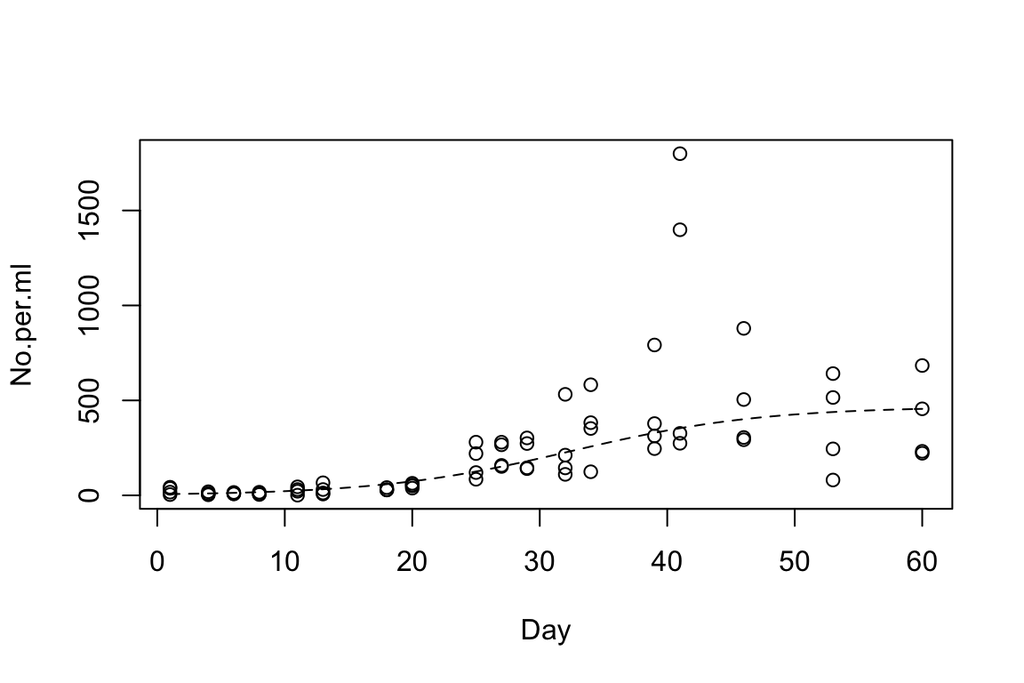

```r
plot(No.per.ml ~ Day, ClostExp, subset = Nutrients == "high")
curve(ilogistic(x, alpha = -cfs[2]/cfs[1], N0 = 6, r = cfs[1]),
      1, 60, add = T, lty = 2)
```

```r
### fig 3.19
```

```r
Cmod.list <- nlsList(No.per.ml ~ ilogistic(Day, alpha, N0, r) | ID,
                     data = ClostExp, start = c(alpha = 1/100, N0 = 5, r = 0.15),
                     control = list(maxiter = 1000))
```

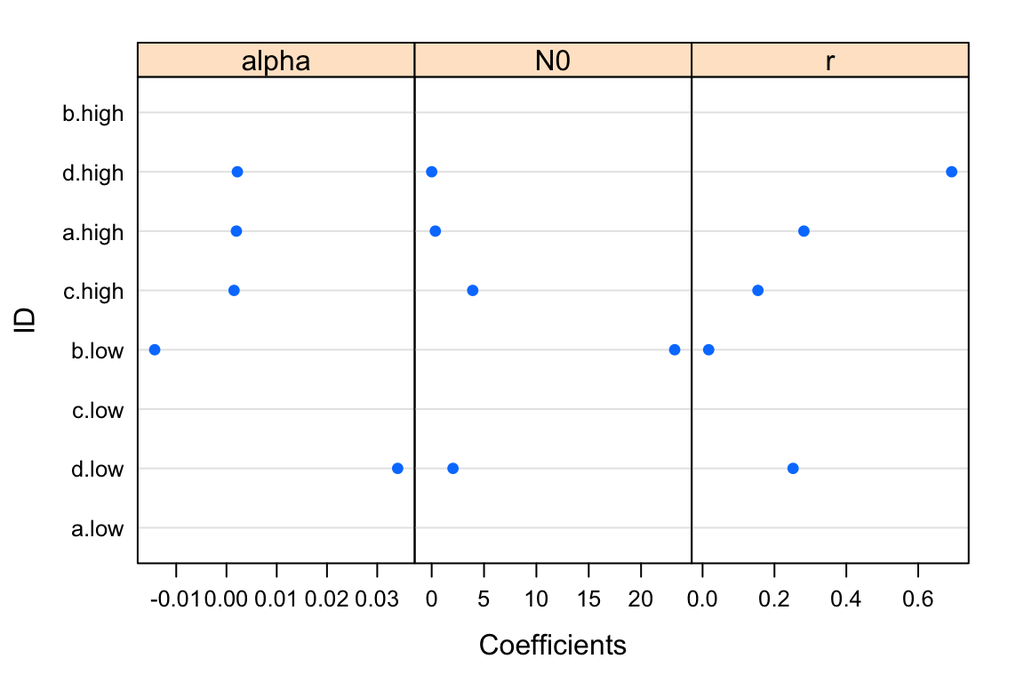

```r
plot(coef(Cmod.list), layout = c(3, 1, 1))
```

```r
### fig. 3.20
```

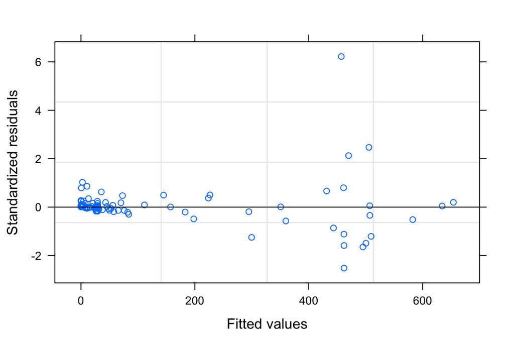

```r
plot(Cmod.list)
```

```r
Cmod.all <- nlme(Cmod.list, random = pdDiag(form = alpha + N0 + r ~ 1),
                 weights = varPower())
```

```r
cfs2 <- fixef(Cmod.all)
cfs2
```

```
##       alpha          N0           r
## 0.009266423 7.142630103 0.130556902
```

```r
Cmod.all2 <- update(Cmod.all, fixed = list(alpha ~ Nutrients, N0 + r ~ 1),
                    start = c(cfs2[1], 0, cfs2[2], cfs2[3]))
```

```r
summary(Cmod.all2)
```

```
## Nonlinear mixed-effects model fit by maximum likelihood
##   Model: No.per.ml ~ ilogistic(Day, alpha, N0, r)
##  Data: ClostExp
##        AIC      BIC    logLik
##   1552.273 1579.001 -767.1364
##
## Random effects:
##  Formula: list(alpha ~ 1, N0 ~ 1, r ~ 1)
##  Level: ID
##  Structure: Diagonal
##         alpha.(Intercept)           N0            r Residual
## StdDev:      1.567021e-07 2.922712e-37 7.236812e-06 1.435784
##
## Variance function:
##  Structure: Power of variance covariate
##  Formula: ~fitted(.)
##  Parameter estimates:
##     power
## 0.8696279
## Fixed effects: list(alpha ~ Nutrients, N0 + r ~ 1)
##                       Value Std.Error  DF  t-value p-value
## alpha.(Intercept)  0.001582 0.0003281 133 4.821261       0
## alpha.Nutrientslow 0.016352 0.0025948 133 6.302111       0
## N0                 6.925089 1.5225307 133 4.548407       0
## r                  0.133419 0.0139953 133 9.533138       0
##  Correlation:
##                    al.(I) alph.N N0
## alpha.Nutrientslow -0.027
## N0                 -0.316  0.064
## r                   0.584  0.020 -0.807
##
## Standardized Within-Group Residuals:
##        Min         Q1        Med         Q3        Max
## -1.3790526 -0.6307898 -0.2574813  0.3482606  4.5330324
##
## Number of Observations: 144
## Number of Groups: 8
```

```r
Cmod.all3 <- update(Cmod.all2, random = N0 ~ 1)
anova(Cmod.all2, Cmod.all3)
```

```
##           Model df      AIC      BIC    logLik   Test  L.Ratio p-value
## Cmod.all2     1  9 1552.273 1579.001 -767.1364
## Cmod.all3     2  7 1544.545 1565.333 -765.2724 1 vs 2 3.728112   0.155
```

```r
intervals(Cmod.all3)$fixed
```

```
##                           lower        est.       upper
## alpha.(Intercept)  0.0009780819 0.001599084 0.002220085
## alpha.Nutrientslow 0.0110953650 0.016205678 0.021315990
## N0                 3.2799366658 6.057370162 8.834803659
## r                  0.1107388041 0.138859646 0.166980488
## attr(,"label")
## [1] "Fixed effects:"
```

```r
1/intervals(Cmod.all3)$fixed[1:2, c(1, 3)]
```

```
##                         lower     upper
## alpha.(Intercept)  1022.40922 450.43318
## alpha.Nutrientslow   90.12772  46.91314
```

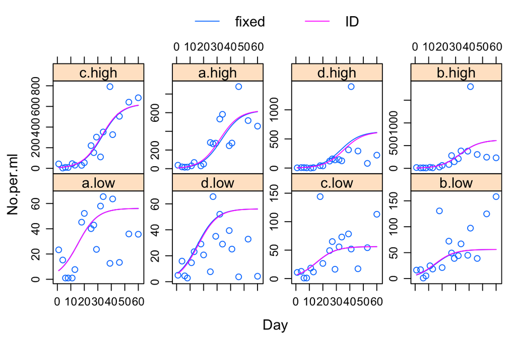

```r
plot(augPred(Cmod.all3, level = 0:1), layout = c(4, 2, 1),
     scales = list(y = list(relation = "free")))
```